# Unsupervised Learning

- author: **Hynek Zemanec**
- year: **SS 2021**

## How to run

This file can be viewed in a browser as:

- static HTML page
- dynamic [Jupyter Notebook](https://jupyter.org/) with runnable code

> Note that if you want to run the code to verify the results, it is necessary to include the original source data files presented below within the root directory of the Jupyter Notebook file:
1. `seeds.csv`
2. `dataset1_noCluster15.csv`
3. `dataset2_noCluster2.csv`
4. `dataset3_noCluster2.csv`
5. `dataset4_noCluster2.csv`
6. `songs.txt`
- [Instructions](https://drive.google.com/file/d/179ky1lTFq7GpUSgSUWbOcQs6sPtiQaHc/view)

```python
# imports and general project settings
%config IPCompleter.greedy=True
import numpy as np
from numpy.linalg import eig
import matplotlib.pyplot as plt
import sklearn
from sklearn import decomposition
from sklearn.decomposition import PCA
```

## Task 1 - PCA

```python
# load data
data = np.genfromtxt("seeds.csv", delimiter=",")
```

### a) Implement PCA

```python
# n:= number of PC
def PCA(data, n):
    # center by subtracting the mean
    centered = (data - np.mean(data, axis=0))
    # covariance matrix of centered data, columns are variables
    cov = np.cov(centered, rowvar=False)
    # from covariance matrix decompose eigen values and vectors
    eigenVals, eigenVecs = eig(cov)
    # sort in Descending order
    eigenValsDESC = np.sort(eigenVals)[::-1]
    # same order for eigenvectors
    eigenVecsDESC = eigenVecs[:,np.argsort(eigenVals)[::-1]]
    # choose n components
    sub = eigenVecsDESC[:, 0:n]
    subLow = eigenVecsDESC[:, -n:]
    # return reduced
    reduced = np.dot(sub.T, centered.T).T
    reducedLowest = np.dot(subLow.T, centered.T).T

    varExplained = eigenValsDESC
    varExplainedRatio = (varExplained / np.sum(varExplained))

    return reduced, reducedLowest, varExplained, varExplainedRatio
```

### b)

Below code demonstrates the usage of the function `PCA()` above, implementing *[Principle Component Analysis](https://en.wikipedia.org/wiki/Principal_component_analysis)*.

Comparison is made between the results of the own implementation and the results from **sklearn** package. Although neither values of explained variance nor explained variance ratio are exactly the same as the values delivered by mentioned package, their difference is negligable.

#### Explained Variance

> In the context of PCA *Explained Variance* is a measure of variability that tells us how much information contained in the data from given dataset is covered (explained) by each of the principal components (eigenvectors). It introduces a notion of importance among feature variables. In other words, it tells us which variables should be kept and which can be safely discarded without loosing too much information.

#### Explained Variance Ratio

> *Explained variance Ratio* is the proportion of explained variance to the sum of values of *Explained Variance*, i.e. the ratio illustrates a percentage of "importance" to given principal component.

```python
# Remove headings and Type label from the dataset
excludedData = np.array([i[:-1] for i in data[1:]]) # shape => (198, 7)

#call implemented function
pcaReduced, pcaReducedLowest, pcaVarExplained, pcaVarExplainedRatio = PCA(excludedData, 2)

#compare to sklearn
pcaCompare = decomposition.PCA(n_components=7).fit(excludedData)

print(f'Explained variance:\n{pcaVarExplained}\n')
print(f'Explained variance ratio:\n{pcaVarExplainedRatio}')
print("\n------\n")
print(f'Explained variance from \033[1msklearn\033[0m:\n{pcaCompare.explained_variance_}\n')
print(f'Explained variance ratio from \033[1msklearn\033[0m:\n{pcaCompare.explained_variance_ratio_}')
print("\n------\n")
print(f'Side-by-side comparison -> list(pcaVarExplained, \033[1mpcaCompare.explained_variance_\033[0m) \n')
print(list(zip(pcaVarExplained,pcaCompare.explained_variance_)))
print("\n")
print(f'Side-by-side comparison -> list(pcaVarExplainedRatio, \033[1mpcaCompare.explained_variance_ratio\033[0m) \n')
print(list(zip(pcaVarExplainedRatio,pcaCompare.explained_variance_ratio_)))
```

```
Explained variance:
[1.08516254e+01 2.04834826e+00 7.37914840e-02 1.27479228e-02
 2.75600772e-03 1.58425236e-03 2.91698076e-05]

Explained variance ratio:
[8.35326268e-01 1.57675836e-01 5.68025183e-03 9.81297676e-04
 2.12149385e-04 1.21951096e-04 2.24540616e-06]

------

Explained variance from sklearn:
[1.08516254e+01 2.04834826e+00 7.37914840e-02 1.27479228e-02
 2.75600772e-03 1.58425236e-03 2.91698076e-05]

Explained variance ratio from sklearn:
[8.35326268e-01 1.57675836e-01 5.68025183e-03 9.81297676e-04
 2.12149385e-04 1.21951096e-04 2.24540616e-06]

------

Side-by-side comparison -> list(pcaVarExplained, pcaCompare.explained_variance_)

[(10.851625373019699, 10.851625373019694), (2.0483482601553993, 2.0483482601553975), (0.07379148395331016, 0.0737914839533098), (0.012747922781861909, 0.01274792278186188), (0.002756007724480873, 0.00275600772448071), (0.001584252359743769, 0.0015842523597441067), (2.916980755457417e-05, 2.916980755…


Side-by-side comparison -> list(pcaVarExplainedRatio, pcaCompare.explained_variance_ratio)

[(0.8353262681149524, 0.8353262681149523), (0.1576758364889288, 0.15767583648892874), (0.005680251832378758, 0.005680251832378732), (0.0009812976763891976, 0.0009812976763891959), (0.00021214938483873978, 0.0002121493848387273), (0.00012195109634980091, 0.00012195109634982695), (2.2454061625436794e-…
```

### c)

```
[]
```

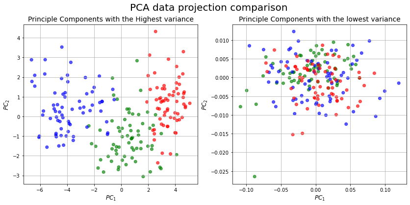

```python
labels = []
for i in data[1:,7]:
    if i == 1:
        labels.append("green")
    elif i == 2:
        labels.append("blue")
    elif i == 3:
        labels.append("red")

fig, axis = plt.subplots(1, 2, figsize=(14,6))
axis[0].scatter(pcaReduced[:,0], pcaReduced[:,1], color=labels, alpha=0.65)
axis[0].grid()
axis[0].set_xlabel("$PC_{1}$", fontsize=12)
axis[0].set_ylabel("$PC_{2}$", fontsize=12)
axis[0].set_title(f'Principle Components with the Highest variance', fontsize=14)
axis[1].scatter(pcaReducedLowest[:,0], pcaReducedLowest[:,1], color=labels, alpha=0.65)
axis[1].grid()
axis[1].set_xlabel("$PC_{1}$", fontsize=12)
axis[1].set_ylabel("$PC_{2}$", fontsize=12)
axis[1].set_title(f'Principle Components with the lowest variance', fontsize=14)
fig.suptitle("PCA data projection comparison", fontsize=20)
plt.plot()
```

## Task 2 - Clustering

```python
from sklearn.cluster import DBSCAN
from sklearn.cluster import KMeans
from sklearn.mixture import GaussianMixture
from sklearn.cluster import AgglomerativeClustering
from sklearn import preprocessing
from sklearn.metrics.cluster import normalized_mutual_info_score
from sklearn.metrics.cluster import adjusted_rand_score
```

### a) importing and preprocessing data

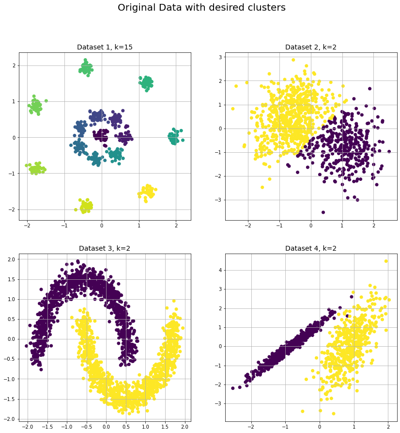

```python
# load data
data1 = np.genfromtxt("dataset1_noCluster15.csv", delimiter=",")
data2 = np.genfromtxt("dataset2_noCluster2.csv", delimiter=",")
data3 = np.genfromtxt("dataset3_noCluster2.csv", delimiter=",")
data4 = np.genfromtxt("dataset4_noCluster2.csv", delimiter=",")

# preprocess data
transData1 = preprocessing.StandardScaler().fit_transform(data1)
transData2 = preprocessing.StandardScaler().fit_transform(data2)
transData3 = preprocessing.StandardScaler().fit_transform(data3)
transData4 = preprocessing.StandardScaler().fit_transform(data4)

labels = [data1[1:,2], data2[1:,2], data3[1:,2], data4[1:,2]]

fig, axis = plt.subplots(2, 2, figsize=(14,14))
fig.suptitle("Original Data with desired clusters", fontsize=20)
axis[0][0].scatter(transData1[1:,0], transData1[1:,1], c=data1[1:,2])
axis[0][0].set_title(f'Dataset 1, k=15', fontsize=14)
axis[0][0].grid()
axis[0][1].scatter(transData2[1:,0], transData2[1:,1], c=data2[1:,2])
axis[0][1].set_title(f'Dataset 2, k=2', fontsize=14)
axis[0][1].grid()
axis[1][0].scatter(transData3[1:,0], transData3[1:,1], c=data3[1:,2])
axis[1][0].set_title(f'Dataset 3, k=2', fontsize=14)
axis[1][0].grid()
axis[1][1].scatter(transData4[1:,0], transData4[1:,1], c=data4[1:,2])
axis[1][1].set_title(f'Dataset 4, k=2', fontsize=14)
axis[1][1].grid()
```

### b) clustering techniques

#### DBSCAN

DBSCAN works best for clustering data sets that are not necessarily radial. The DBSCAN algorithm accepts epsilon a "distance radius" surrounding each data point and minimum number of samples for a point tobe considered a core point and accordingly the group to be considered a cluster. For best results it is neccessary to have a rough idea about the shape of data. It favors shapes that can be distinct, being immune to outliers unlike other clustering algorithms. Used parameters must be always selected based on the "distances" of the data and hence are fine-tuned as a result of multiple iterations of trial & error.

In theory DBSCAN would be my first choice if I did not know the shape of the data for the reason of being immune to outliers.

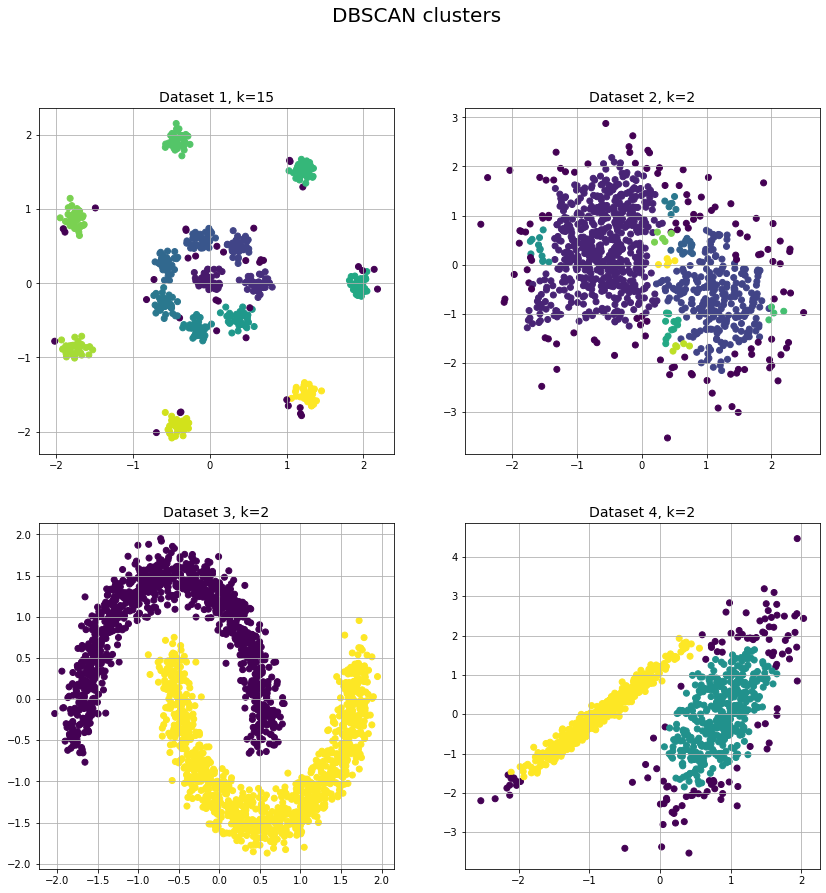

```python
dbscanClusters1 = DBSCAN(eps=0.1, min_samples=5).fit_predict(transData1[1:,0:2])
dbscanClusters2 = DBSCAN(eps=0.17).fit_predict(transData2[1:,0:2])
dbscanClusters3 = DBSCAN(eps=0.3, min_samples=5).fit_predict(transData3[1:,0:2])
dbscanClusters4 = DBSCAN(eps=0.205, min_samples=10).fit_predict(transData4[1:,0:2])

dbscanClusters = [dbscanClusters1, dbscanClusters2, dbscanClusters3, dbscanClusters4]

fig, axis = plt.subplots(2, 2, figsize=(14,14))
fig.suptitle("DBSCAN clusters", fontsize=20)
axis[0][0].scatter(transData1[1:,0], transData1[1:,1], c=dbscanClusters1)
axis[0][0].set_title(f'Dataset 1, k=15', fontsize=14)
axis[0][0].grid()
axis[0][1].scatter(transData2[1:,0], transData2[1:,1], c=dbscanClusters2)
axis[0][1].set_title(f'Dataset 2, k=2', fontsize=14)
axis[0][1].grid()
axis[1][0].scatter(transData3[1:,0], transData3[1:,1], c=dbscanClusters3)
axis[1][0].set_title(f'Dataset 3, k=2', fontsize=14)
axis[1][0].grid()
axis[1][1].scatter(transData4[1:,0], transData4[1:,1], c=dbscanClusters4)
axis[1][1].set_title(f'Dataset 4, k=2', fontsize=14)
axis[1][1].grid()
```

#### K-Means

K-means has been chosen as it is foundational clustering algorithm and arguably the most well-known among the alternatives. Algorithm clusters the best datasets that are have radial clusters, requiring the number of clusters (k) to be specified beforehand. Accordingly, number of clusters must be known in advance to produce meaningful results.

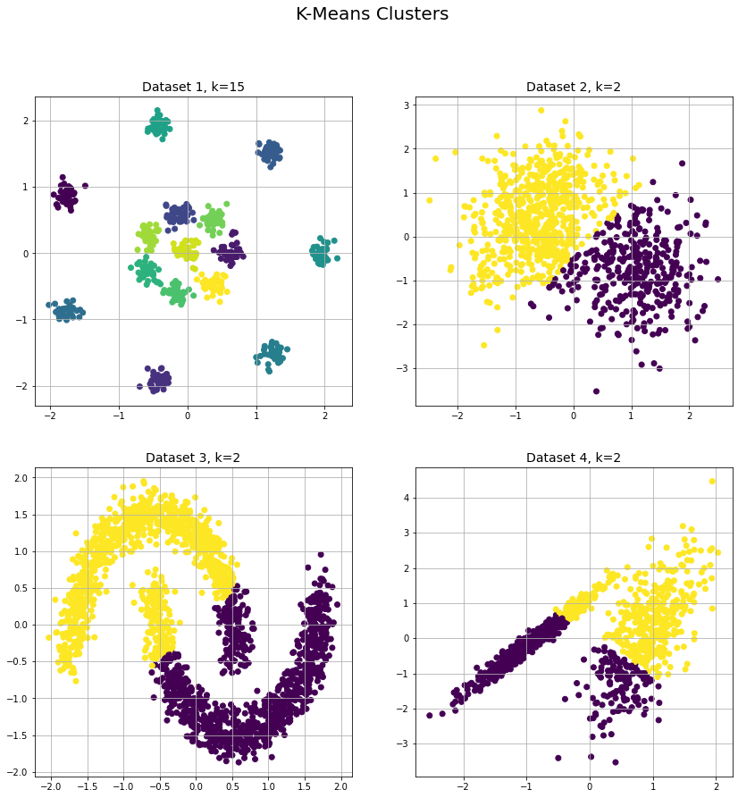

```python
kmeansClusters1 = KMeans(n_clusters=15).fit_predict(transData1[1:,0:2])
kmeansClusters2 = KMeans(n_clusters=2).fit_predict(transData2[1:,0:2])
kmeansClusters3 = KMeans(n_clusters=2).fit_predict(transData3[1:,0:2])
kmeansClusters4 = KMeans(n_clusters=2).fit_predict(transData4[1:,0:2])

kmeansClusters = [kmeansClusters1, kmeansClusters2, kmeansClusters3, kmeansClusters4]

fig, axis = plt.subplots(2, 2, figsize=(14,14))
fig.suptitle("K-Means Clusters", fontsize=20)
axis[0][0].scatter(transData1[1:,0], transData1[1:,1], c=kmeansClusters1)
axis[0][0].set_title(f'Dataset 1, k=15', fontsize=14)
axis[0][0].grid()
axis[0][1].scatter(transData2[1:,0], transData2[1:,1], c=kmeansClusters2)
axis[0][1].set_title(f'Dataset 2, k=2', fontsize=14)
axis[0][1].grid()
axis[1][0].scatter(transData3[1:,0], transData3[1:,1], c=kmeansClusters3)
axis[1][0].set_title(f'Dataset 3, k=2', fontsize=14)
axis[1][0].grid()
axis[1][1].scatter(transData4[1:,0], transData4[1:,1], c=kmeansClusters4)
axis[1][1].set_title(f'Dataset 4, k=2', fontsize=14)
axis[1][1].grid()
```

#### Expectation Maximization

Similar clustering technique to K-means, EM expects the number of clusters to be specified beforehand, ususally performing similarly as K-means.

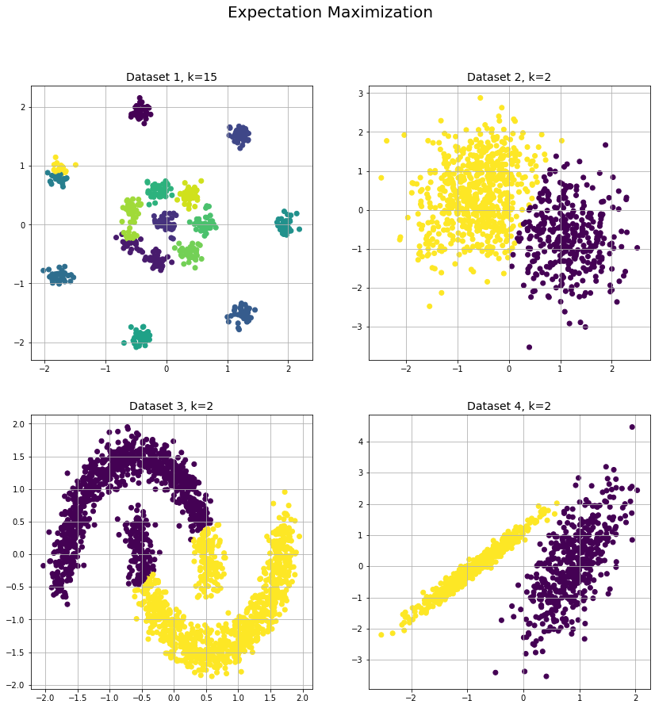

```python
EMClusters1 = GaussianMixture(n_components=15).fit_predict(transData1[1:,0:2])
EMClusters2 = GaussianMixture(n_components=2).fit_predict(transData2[1:,0:2])
EMClusters3 = GaussianMixture(n_components=2).fit_predict(transData3[1:,0:2])
EMClusters4 = GaussianMixture(n_components=2).fit_predict(transData4[1:,0:2])

EMClusters = [EMClusters1, EMClusters2, EMClusters3, EMClusters4]

fig, axis = plt.subplots(2, 2, figsize=(14,14))
fig.suptitle("Expectation Maximization", fontsize=20)
axis[0][0].scatter(transData1[1:,0], transData1[1:,1], c=EMClusters1)
axis[0][0].set_title(f'Dataset 1, k=15', fontsize=14)
axis[0][0].grid()
axis[0][1].scatter(transData2[1:,0], transData2[1:,1], c=EMClusters2)
axis[0][1].set_title(f'Dataset 2, k=2', fontsize=14)
axis[0][1].grid()
axis[1][0].scatter(transData3[1:,0], transData3[1:,1], c=EMClusters3)
axis[1][0].set_title(f'Dataset 3, k=2', fontsize=14)
axis[1][0].grid()
axis[1][1].scatter(transData4[1:,0], transData4[1:,1], c=EMClusters4)
axis[1][1].set_title(f'Dataset 4, k=2', fontsize=14)
axis[1][1].grid()
```

#### Average Link

Average Link also known as Agglomerative Clustering accepts number of clusters that need to be known in advance for the algorithm to perform well. The technique utilizes 3 properties:

- Single Linkage : distance between the closest members of 2 distinct clusters
- Complete Linkage : greatest possible distance of 2 members of 2 distinct clusters
- Average Linkage : average distance calculated based on distances between all points of 2 clusters

The distance is typically calculated as Euclidean distance.

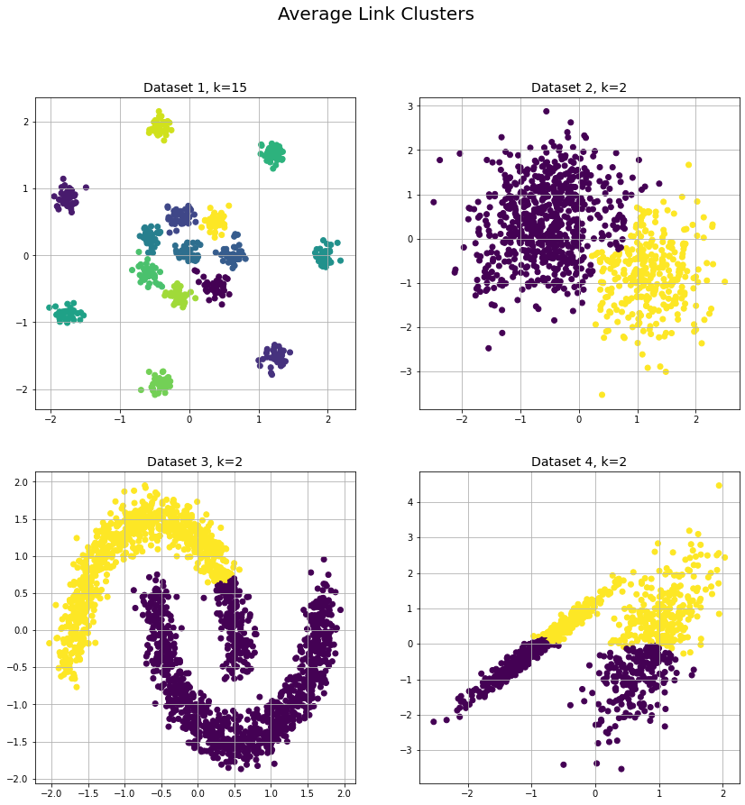

```python
ALClusters1 = AgglomerativeClustering(n_clusters=15).fit_predict(transData1[1:,0:2])
ALClusters2 = AgglomerativeClustering(n_clusters=2).fit_predict(transData2[1:,0:2])
ALClusters3 = AgglomerativeClustering(n_clusters=2).fit_predict(transData3[1:,0:2])
ALClusters4 = AgglomerativeClustering(n_clusters=2).fit_predict(transData4[1:,0:2])

ALClusters = [ALClusters1, ALClusters2, ALClusters3, ALClusters4]

fig, axis = plt.subplots(2, 2, figsize=(14,14))
fig.suptitle("Average Link Clusters", fontsize=20)
axis[0][0].scatter(transData1[1:,0], transData1[1:,1], c=ALClusters1)
axis[0][0].set_title(f'Dataset 1, k=15', fontsize=14)
axis[0][0].grid()
axis[0][1].scatter(transData2[1:,0], transData2[1:,1], c=ALClusters2)
axis[0][1].set_title(f'Dataset 2, k=2', fontsize=14)
axis[0][1].grid()
axis[1][0].scatter(transData3[1:,0], transData3[1:,1], c=ALClusters3)
axis[1][0].set_title(f'Dataset 3, k=2', fontsize=14)
axis[1][0].grid()
axis[1][1].scatter(transData4[1:,0], transData4[1:,1], c=ALClusters4)
axis[1][1].set_title(f'Dataset 4, k=2', fontsize=14)
axis[1][1].grid()
```

### c) Evaluate

```python
print("NMI: Normalized Mutual Information \nRMI: Random Index \n\n---\n")
def Evaluate(clusteringMethod, predicted, originalLabels):
    index = 0
    for i in originalLabels:
        print(f'NMI for {clusteringMethod} on dataset {index + 1}:'.ljust(48) + f'{normalized_mutual_info_score(predicted[index],i)}')
        print(f'ARS for {clusteringMethod} on dataset {index + 1}:'.ljust(48) + f'{adjusted_rand_score(predicted[index],i)}')
        index += 1
    print("---")

Evaluate("DBSCAN", dbscanClusters, labels)
Evaluate("K-Means", kmeansClusters, labels)
Evaluate("Expectation Maximization", EMClusters, labels)
Evaluate("Average Link", ALClusters, labels)
```

```
NMI: Normalized Mutual Information
RMI: Random Index

---

NMI for DBSCAN on dataset 1:                    0.9276579442944719
ARS for DBSCAN on dataset 1:                    0.9001872883495454
NMI for DBSCAN on dataset 2:                    0.4898037657312523
ARS for DBSCAN on dataset 2:                    0.5951474162870526
NMI for DBSCAN on dataset 3:                    1.0
ARS for DBSCAN on dataset 3:                    1.0
NMI for DBSCAN on dataset 4:                    0.7695570848436747
ARS for DBSCAN on dataset 4:                    0.8002200593285234
---
NMI for K-Means on dataset 1:                   0.9942285075104653
ARS for K-Means on dataset 1:                   0.9927781994136302
NMI for K-Means on dataset 2:                   1.0
ARS for K-Means on dataset 2:                   1.0
NMI for K-Means on dataset 3:                   0.3741491905843432
ARS for K-Means on dataset 3:                   0.47170472683052145
NMI for K-Means on dataset 4:                   0.19779964541938183
ARS for K-Means on dataset 4:                   0.25936128115906326
---
NMI for Expectation Maximization on dataset 1:  0.9569265236689255
ARS for Expectation Maximization on dataset 1:  0.8914398641671174
NMI for Expectation Maximization on dataset 2:  0.7501730591247739
ARS for Expectation Maximization on dataset 2:  0.8452968136183219
NMI for Expectation Maximization on dataset 3:  0.38766614295965374
ARS for Expectation Maximization on dataset 3:  0.4869473463724778
NMI for Expectation Maximization on dataset 4:  0.9623775427101197
ARS for Expectation Maximization on dataset 4:  0.984048032191744
---
NMI for Average Link on dataset 1:              0.9864167293669317
ARS for Average Link on dataset 1:              0.9819955008205571
NMI for Average Link on dataset 2:              0.7357449204481069
ARS for Average Link on dataset 2:              0.7970865476906515
NMI for Average Link on dataset 3:              0.6238811959373672
ARS for Average Link on dataset 3:              0.6462458327427875
NMI for Average Link on dataset 4:              0.014627338822927443
ARS for Average Link on dataset 4:              0.019184851141208877
---
```

### d) Result discussion

For dataset from `dataset3_noCluster2.csv` DBSCAN clusters the data perfectly. The scatter plot of the data is an example where DBSCAN performs the best. DBSCAN is advantageous to using other algoritms used that perform better on the radial compositions of data points.

For dataset from `dataset4_noCluster2.csv` the best results are produced by Expectation Maximization algorithm followed by DBSCAN. The shape of the data is not necessarily evenly distributed, but we can observe two rather different distinguishible shapes. That's why mentioned algorithms vastly outperform K-Means.

## Task 3 - Apriori Algorithm

```python
import math

# import and preprocess data
database = []
items = set()
relativeMinSupp = 0.01

# put transactions in a database
with open("songs.txt", "r") as file:
    for user in file:
        database.append(set(user.replace("\n", "").split(";")))

# create set of all songs
for transaction in database:
    items.update(transaction)

#calculate absolute support
absMinSupp = math.floor(relativeMinSupp * len(items))
```

### a) length 1 frequent sets

```python
def countSupport(item, database, multiple=False):
    support = 0
    if (multiple is False):
        itemSet = set([item])
    else:
        itemSet = set(item)
    for transaction in database:
        if(itemSet.issubset(transaction)):
            support += 1
    return support

def getL1(items, database):
    L1 = []
    for song in items:
        support = countSupport(song, database)
        if(support > absMinSupp):
            L1.append({support:song})
    return L1

L1 = getL1(items, database)

form="%s\n"
with open("oneItems.txt",'w') as file:
    for i in L1:
        for key, value in i.items():
            file.write('{}:{}\n'.format(key,''.join(value)))
```

### b) All frequent itemset

```python
from itertools import combinations

# Return candidate with insufficient support
def getL1Removed(items, database):
    L1removed = set()
    for song in items:
        # generate combinations
        support = countSupport(song, database)
        if(support <= absMinSupp):
            L1removed.add(song)
    return L1removed

# Get candidates for set of size n:=membesInSet
def generateCandidates(items, database, membersInSet):
    C = set()
    for transaction in database:
        for i in list(combinations(transaction, membersInSet)):
            C.add(frozenset(i))
    return C

# frequent Itemsets based on the supplied candidates and DB
def getFrequent(candidateSet, database):
    res = []
    for i in candidateSet:
        counter = 0
        for j in database:
            if (i.issubset(j)):
                counter += 1
        if(counter > absMinSupp):
            res.append({counter:i})
    return res
```

```python
import copy

L2DB = copy.deepcopy(database)
L1Removed = getL1Removed(items, database)

# optimization by deleting irrelevant itemsets
for transaction in L2DB:
    for removed in L1Removed:
        if(removed in transaction):
            transaction.remove(removed)

# Length 2 Itemsets
# disjunction a.k.a. set difference
updatedItemset = items - L1Removed
C2 = generateCandidates(updatedItemset, L2DB, 2)

L2 = getFrequent(C2, L2DB)
print(L2)
```

```
[{19: frozenset({'Stairway To Heaven', 'Sin City'})}, {19: frozenset({"Rockin' In the Free World", 'Back On The Chain Gang'})}, {19: frozenset({'Are You Gonna Go My Way', "Tuesday's Gone"})}, {22: frozenset({"Don't Stop Me Now", 'Ride the Tiger'})}, {19: frozenset({'My Kinda Lover', 'Elected'})}, {2…
```

```python
# Takes a long time to compute, 15+ mins
C3 = generateCandidates(updatedItemset, L2DB, 3)
L3 = getFrequent(C3, L2DB)

print(L3)
```

```
[{19: frozenset({"Knockin' On Heaven's Door", 'Look What The Cat Dragged In', 'Hotel California'})}, {20: frozenset({'Just Like A Woman', "Knockin' On Heaven's Door", 'Stairway To Heaven'})}, {22: frozenset({"Knockin' On Heaven's Door", 'Stairway To Heaven', 'Hotel California'})}, {19: frozenset({"K…
```

> Please note, that getting Candidates and determining Frequent Itemsets for Itemsets of size 3 and more, takes a long time ( > 10 min, in the enviornment of the author).

```python
print(f'Frequent itemsets in L2: {len(L2)}')
print(f'Frequent itemsets in L3: {len(L3)}')

# final formating
frequentItemsets = []

for i in L1:
    frequentItemsets.append(str(list(i)[0]) + ":" +list(i.values())[0])

for itemset in L2:
    for subset in itemset.values():
        vals = ";".join([str(s) for s in subset])
    frequentItemsets.append(f'{list(itemset.keys())[0]}:{vals}')

for itemset in L3:
    for subset in itemset.values():
        vals = ";".join([str(s) for s in subset])
    frequentItemsets.append(f'{list(itemset.keys())[0]}:{vals}')

# write results to the text file
with open("patterns.txt",'w') as file:
    for line in frequentItemsets:
        file.writelines(line+'\n')
```

```
Frequent itemsets in L2: 548
Frequent itemsets in L3: 16
```

### c) Song Recommendation for a User

for the set of songs `Hotel California` and `Knockin' On Heaven's Door` (support 26)

```python
userPref = {"Hotel California", "Knockin' On Heaven's Door"}

L3VSets = [list(i.values())[0] for i in L3]

recommend = []

for i in L3VSets:
    if userPref.issubset(i):
        # set difference
        recommend.append(i - userPref)

# Final Verdict
index = 0
for i in recommend:
    print(f'Recommended song #{index} for the user: {list(i)[0]}')
    index += 1
```

```
Recommended song #0 for the user: Look What The Cat Dragged In
Recommended song #1 for the user: Stairway To Heaven
```

Based on the results of the Apriori Algorithm implemented above, there are 2 songs that could be recommended to the user:

The corresponding supports needed to calculate confidence can be easily retrieved by searching through the `patterns.txt` containing Itemsets and their support.

For calculating confidence the following formula has been used:

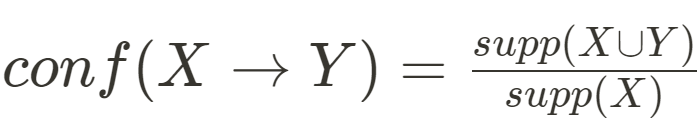

In simple terms, it represents how often items in itemset `Y` appear in transactions that contain items of itemset `X`.

Accordingly, both `Stairway To Heaven` and `Look What The Cat Dragged In` appear in itemsets that also contain preferred items by the user `Hotel California` `Knockin' On Heaven's Door`.

The itemset `{Hotel California, Knockin' On Heaven's Door}` appears 26 times and hence has support 26.